# Report on the Influence of Activating Factor 42 on Gene Expression

James Day, a1820798

2024-05-30

## Introduction

Gene expression is the process whereby information from a gene is used to synthesise gene products - such as proteins - and is fundamental to cellular function and the eventual determination of phenotypes. Regulation of gene expression is a complex process that is influenced by various stimuli from the intracellular and extracellular environments.

Activating Factor 42 is a novel compound that has been hypothesised to significantly influence gene expression. This study aims to quantify the changes in gene expression levels induced by Activating Factor 42, in comparison to a placebo treatment of saline, for increasing concentrations of growth factor. We assess the variability of these effects across two different cell lines, specifically Wild-type and Cell-type 101.

By addressing these objectives, we may demonstrate the potential of Activating Factor 42 as a modulator of gene expression and its potential biomedical applications. Understanding the detailed mechanisms and effects of this factor can provide insights into its therapeutic potential and inform future studies aimed at developing new treatments for diseases characterised by dysregulated gene expression.

Table 1: Summary of Gene Expression by Cell Line and Treatment

| Cell Line | Mean Gene Expression | Minimum Gene Expression | Median Gene Expression | Maximum Gene Expression | STDEV Gene Expression | Total Observations |
| --- | --- | --- | --- | --- | --- | --- |
| Activating Factor 42 |  |  |  |  |  |  |
| Cell-type 101 | 16.64 | 7.45 | 10.91 | 38.52 | 10.11 | 22 |
| Wild-type | 21.85 | 9.32 | 19.27 | 44.44 | 9.99 | 22 |
| Placebo |  |  |  |  |  |  |
| Cell-type 101 | 14.17 | 7.15 | 14.05 | 23.24 | 5.19 | 22 |
| Wild-type | 4.59 | 2.58 | 4.69 | 6.67 | 1.12 | 22 |

By comparing to Table 1, we may summarise the dependence of gene expression on growth factor concentration and treatment across both cell lines in Table 2. The mean and median gene expressions after treatment with Activating Factor 42 exceed the gene expressions with saline for all concentrations of growth factor. The difference between mean treatment and placebo gene expressions is almost strictly increasing. The standard deviation for gene expression is also higher for Activating Factor 42, as expected from Table 1. Note that the minimum gene expression for Activating Factor does not usually exceed the maximum gene expression for the placebo, indicating that there may be substantial statistical overlap between the two distributions.

Table 2: Summary of Gene Expression by Concentration and Treatment

| Concentration | Mean Gene Expression | Minimum Gene Expression | Median Gene Expression | Maximum Gene Expression | STDEV Gene Expression | Total Observations |
| --- | --- | --- | --- | --- | --- | --- |
| Activating Factor 42 |  |  |  |  |  |  |
| 0 | 9.77 | 8.12 | 9.77 | 11.40 | 1.39 | 4 |
| 1 | 11.96 | 10.35 | 11.83 | 13.83 | 1.84 | 4 |
| 2 | 14.21 | 9.80 | 14.18 | 18.70 | 3.75 | 4 |
| 3 | 15.43 | 9.46 | 15.96 | 20.32 | 5.22 | 4 |
| 4 | 17.21 | 8.21 | 18.14 | 24.33 | 7.00 | 4 |
| 5 | 19.88 | 8.46 | 21.00 | 29.07 | 9.07 | 4 |
| 6 | 20.38 | 9.44 | 21.12 | 29.83 | 8.93 | 4 |
| 7 | 21.92 | 7.45 | 23.60 | 33.04 | 11.40 | 4 |
| 8 | 24.52 | 8.31 | 26.84 | 36.10 | 12.98 | 4 |
| 9 | 27.44 | 10.27 | 29.36 | 40.77 | 13.75 | 4 |
| 10 | 28.99 | 8.83 | 31.35 | 44.44 | 15.91 | 4 |
| Placebo |  |  |  |  |  |  |
| 0 | 6.47 | 5.05 | 6.54 | 7.75 | 1.21 | 4 |
| 1 | 5.95 | 3.34 | 5.96 | 8.53 | 2.58 | 4 |
| 2 | 8.11 | 5.54 | 7.71 | 11.47 | 2.61 | 4 |
| 3 | 7.95 | 4.89 | 8.00 | 10.89 | 2.80 | 4 |
| 4 | 8.06 | 3.44 | 7.42 | 13.98 | 4.64 | 4 |
| 5 | 9.57 | 4.74 | 8.55 | 16.45 | 5.50 | 4 |
| 6 | 9.70 | 2.58 | 9.38 | 17.45 | 7.21 | 4 |
| 7 | 10.37 | 2.97 | 9.66 | 19.18 | 7.98 | 4 |
| 8 | 12.23 | 3.68 | 11.51 | 22.24 | 8.98 | 4 |
| 9 | 11.95 | 3.46 | 11.36 | 21.61 | 9.18 | 4 |
| 10 | 12.82 | 3.77 | 12.14 | 23.24 | 10.35 | 4 |

## Methods

The experiments aimed to investigate the effect of Activating Factor 42 on gene expression across two different cell lines, namely Cell-type 101 and Wild-type. Additionally, the study explored how gene expression varied in response to different concentrations of a growth factor. The experiment followed a factorial design, with two main factors: treatment (Activating Factor 42 or placebo) and concentration of the growth factor.

Gene expression data was collected and processed using R version 4.2.2 (R Core Team 2022). The packages used for data manipulation, plotting and analysis included readxl (Wickham and Bryan 2019), tidyverse (Wickham et al. 2019), skimr (Waring et al. 2022), gt (Iannone et al. 2024), lme4 (Bates et al. 2015), performance (Lüdecke et al. 2021), lmerTest (Kuznetsova, Brockhoff, and Christensen 2017), ggpubr (Kassambara 2023) and ggrepel (Slowikowski 2024).

The gene expression data was log-transformed to correct for heteroscedasticity, which was confirmed through diagnostic plots and a Box-Cox transformation analysis on the null-intercept model. The model selection was based on the Akaike Information Criterion (AIC), which favored a linear mixed-effects model fit specified by `log(gene_expression) ~ (1 | name) + (conc * treatment):cell_line` in R. Although the principle of marginality applies here, we have no biological reason to believe a priori that the intercepts of gene expression are dependent on the specific cell line. Without greater a sample size to determine if such an effect exists, inclusion of the lower order term would not improve the predictive capacity of the model and simply reduce the model degrees of freedom. Rather, the random intercept captures much of the variability of gene expression for each culture of cell lines when growth factor is absent. Mathematically, we may write the above mixed-effects model for the gene expression $y_{ij}$ of the $j$-th observation from sample $i$ as
$$\mathbb{E}\left[\ln y_{ij}\mid
u_i\right]=\left(\beta_{0}+u_{i}\right)+\beta_{1}x_{j1}x_{j3}+\beta_{2}x_{j2}x_{j3}+\beta_{3}x_{j1}x_{j2}x_{j3},$$
such that $x_{j1}$ is the concentration of growth factor, $x_{j2}$ is a dummy variable for treatment ($1$ for placebo and $0$ for Activating Factor 42), $x_{j3}$ is a dummy variable for cell line, and $u_i$ is an unobserved effect that captures variations in samples cultured from their respective cell lines. For samples with a given applied treatment and concentration of growth factor, those with relatively higher $u_i$ will exhibit higher levels of gene expression on any particular observation.

## Results

In Figure 1, we observe that Activating Factor 42 is successful in promoting gene expression when compared with the placebo for the Wild-type cell line. The gene expression is increasing with respect to growth factor concentration for the treatment, and is impervious to growth factor concentration for the placebo. In Cell-type 101, the effect is ambiguous. For samples, MFA, cwN, and kYH - the latter two treated with saline - exhibit increasing gene expression for higher concentrations of growth factor. However, ZHw remains approximately flat despite being treated with Activating Factor 42.

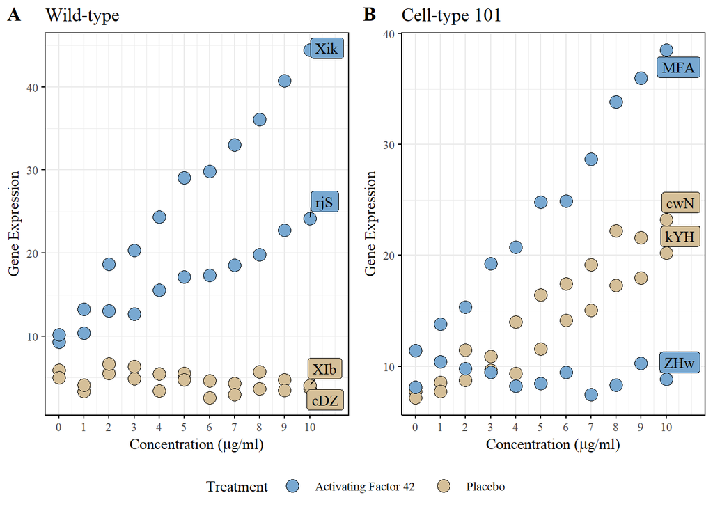

Figure 1: Gene expression observed for the concentrations of growth factor applied, which is grouped by treatment, cell line, and specific sample.

We may illustrate the log-transformed data in Figure 2. Linearity is still preserved and it is clearer that the gene expressions for XIb, cDZ, and ZHw are declining wth respect to growth factor concentration. The difference in the logarithm of gene expression between Xik and rjS or cwN and kYH appears to be bounded which implies that these samples only differ due to a random effect which perturbs the gene expression of a given sample - without any introduction of growth factor.

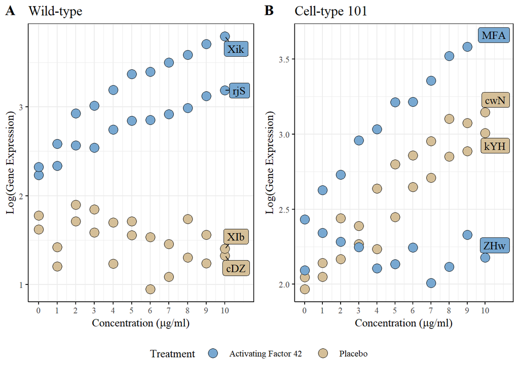

Figure 2: Logarithm of gene expression observed for the concentrations of growth factor applied, which is grouped by treatment, cell line, and specific sample.

We employed a linear mixed-effects model to analyse the log-transformed gene expression, incorporating random effects for individual samples and fixed effects for the interactions between treatment, growth factor concentration, and cell line. The model was fit using Restricted Maximum Likelihood (REML), and t-tests were conducted using Satterthwaite’s method. The REML criterion at convergence was 20.4, indicating a good fit for the model. The scaled residuals ranged from -3.3903 to 2.3792, with a median of 0.1092, suggesting that the model residuals were reasonably well-distributed. The variance attributed to the random intercept for individual samples (grouped by sample name) was 0.09931, with a standard deviation of 0.3151. The residual variance was 0.04155, with a standard deviation of 0.2038. The model included the full dataset of 88 observations across 8 groups. The estimates, standard errors, degrees of freedom, t-values, and significance levels for the fixed effects of the model are summarised in Table 3.

Table 3: Fixed Effects Summary

| Term | Estimate | Std. Error | df | t value | Pr(>\|t\|) |
| --- | --- | --- | --- | --- | --- |
| (Intercept) | 2.3911 | 0.1677 | 5.9404 | 14.2560 | 8.08e-06 *** |
| Concentration:Cell-type 101 | 0.0577 | 0.0134 | 80.4125 | 4.2910 | 4.91e-05 *** |
| Concentration:Wild-type | 0.1143 | 0.0134 | 80.4125 | 8.4930 | 8.39e-13 *** |
| Placebo:Cell-type 101 | −0.3635 | 0.2905 | 5.9404 | −1.2510 | 0.25788 |
| Placebo:Wild-type | −0.7471 | 0.2905 | 5.9404 | −2.5720 | 0.04262 * |
| Concentration:Placebo:Cell-type 101 | 0.0534 | 0.0192 | 78.7084 | 2.7760 | 0.00687 ** |
| Concentration:Placebo:Wild-type | −0.1441 | 0.0192 | 78.7084 | −7.4950 | 8.50e-11 *** |

All terms are significant at the 5% level except for Placebo:Cell-type 101, which estimates a decrease in the intercept for the logarithm of gene expression (esimated to be 2.3911) by 0.3635 when a sample of Cell-type 101 is treated with saline. This is consistent with Figure 2B and it is sensible to keep this term in the model a priori.

When treated with Activating factor 42, we may conclude from the model summary that expected value of logarithmic gene expression increases by 0.0577 for a sample of Cell-type 101 or by 0.1143 for a sample of Wild-type when the concentration of growth factor increases by 1µg/ml. When treated with saline, expected value of logarithmic gene expression increases by 0.111 for a sample of Cell-type 101 or decreases by 0.0298 for a sample of Wild-type when the concentration of growth factor increases by 1µg/ml.

So, Activating factor 42 is no better than a placebo at promoting positive gene expression to growth factor in Cell-type 101 samples but greatly increases positive gene expression to growth factor in Wild-type samples.

With reference to Figure 3, we will test whether the linear regression assumptions of linearity and homoscedasticity are reasonable. Since the residuals perturb randomly above and below the $y=0$ line, we conclude that linearity is reasonable. For the majority of the data, there is no pinching or fanning so homoscedasticity seems reasonable. There is slight fanning of the residuals for small fitted values.

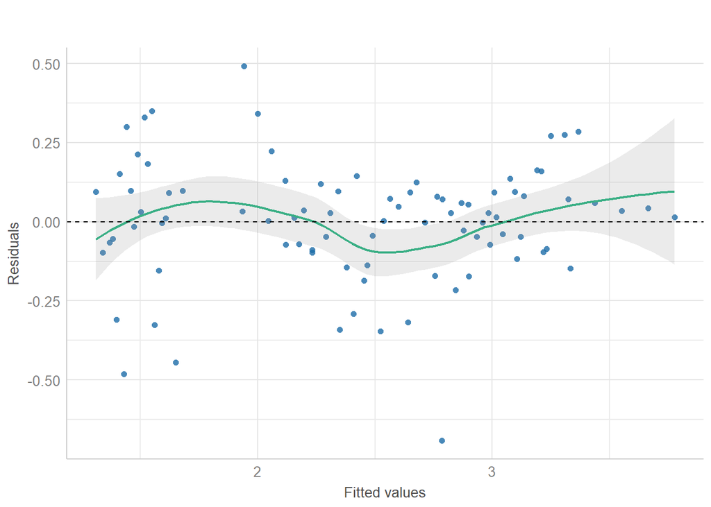

Figure 3: Residuals vs fitted values plot for the mixed-effects model.

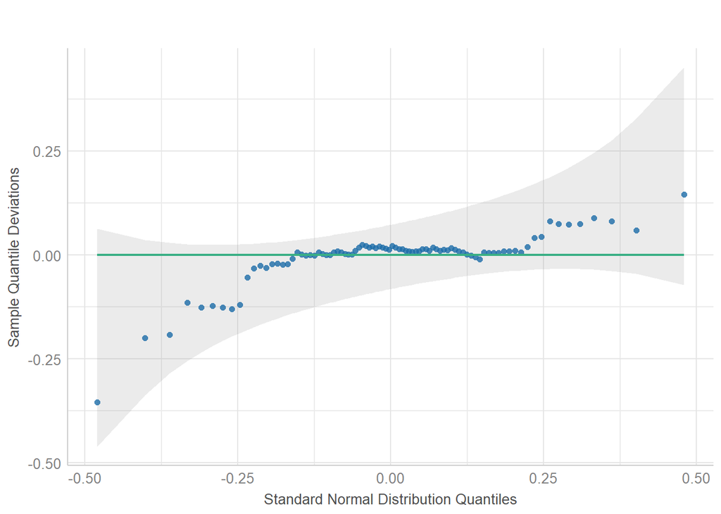

Figure 4: Normal quantile plot of standardised residuals for the mixed-effects model.

According to Figure 5, all data points lie well within Cook’s distance and so there are no outliers that significantly influence the fitted model.

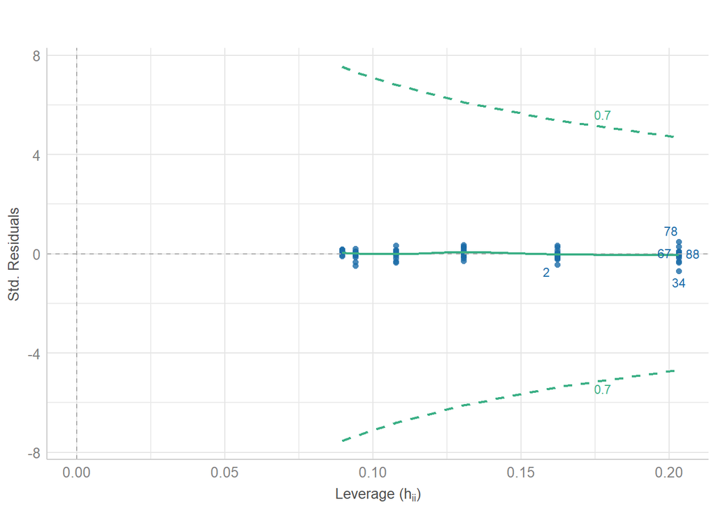

Figure 5: Standardised residuals vs leverage plot for the mixed-effects model. The dashed line is 70% of Cook’s distance.

## Discussion

Our analysis demonstrates that Activating Factor 42 has a statistically significant impact on gene expression and the influence of growth factor on gene expression in both cell lines studied. In cultures from Wild-type, Activating Factor 42 promotes a positive gene expression response to increasing concentrations of growth factor. The response is significantly higher than achieved with saline. In cultures from the Cell-type 101, Activating Factor 42 was no better than saline at promoting a positive gene expression response to increasing concentrations of growth factor. These findings are crucial for developing targeted therapies that leverage the differential sensitivity of cell lines to treatments. Future research should focus on elucidating the molecular mechanisms underpinning these interactions to improve on our presented model, perhaps with larger sample sizes.

## References

Bates, Douglas, Martin Mächler, Ben Bolker, and Steve Walker. 2015. “Fitting Linear Mixed-Effects Models Using lme4.” *Journal of Statistical Software* 67 (1): 1–48. https://doi.org/10.18637/jss.v067.i01.

Iannone, Richard, Joe Cheng, Barret Schloerke, Ellis Hughes, Alexandra Lauer, and JooYoung Seo. 2024. *Gt: Easily Create Presentation-Ready Display Tables*. https://CRAN.R-project.org/package=gt.

Kassambara, Alboukadel. 2023. *Ggpubr: “Ggplot2” Based Publication Ready Plots*. https://CRAN.R-project.org/package=ggpubr.

Kuznetsova, Alexandra, Per B. Brockhoff, and Rune H. B. Christensen. 2017. “lmerTest Package: Tests in Linear Mixed Effects Models.” *Journal of Statistical Software* 82 (13): 1–26. https://doi.org/10.18637/jss.v082.i13.

Lüdecke, Daniel, Mattan S. Ben-Shachar, Indrajeet Patil, Philip Waggoner, and Dominique Makowski. 2021. “performance: An R Package for Assessment, Comparison and Testing of Statistical Models.” *Journal of Open Source Software* 6 (60): 3139. https://doi.org/10.21105/joss.03139.

R Core Team. 2022. *R: A Language and Environment for Statistical Computing*. Vienna, Austria: R Foundation for Statistical Computing. https://www.R-project.org/.

Slowikowski, Kamil. 2024. *Ggrepel: Automatically Position Non-Overlapping Text Labels with ’Ggplot2’*. https://CRAN.R-project.org/package=ggrepel.

Waring, Elin, Michael Quinn, Amelia McNamara, Eduardo Arino de la Rubia, Hao Zhu, and Shannon Ellis. 2022. *Skimr: Compact and Flexible Summaries of Data*. https://CRAN.R-project.org/package=skimr.

Wickham, Hadley, Mara Averick, Jennifer Bryan, Winston Chang, Lucy D’Agostino McGowan, Romain François, Garrett Grolemund, et al. 2019. “Welcome to the tidyverse.” *Journal of Open Source Software* 4 (43): 1686. https://doi.org/10.21105/joss.01686.

Wickham, Hadley, and Jennifer Bryan. 2019. “Readxl: Read Excel Files.” *R Package Version 1.3.1*. https://CRAN.R-project.org/package=readxl.